# STAT 301-2 Final Project

Ashley Fang

3/4/2021

## Introduction

Last quarter, I did an exploratory data analysis of the audio features of over 500 songs from Spotify, with a main focus on K-pop, in order to learn more about it as a music genre instead of a commercialized form of entertainment. At the end of the exploration, I made radar charts of the audio features of 12 different music genres:

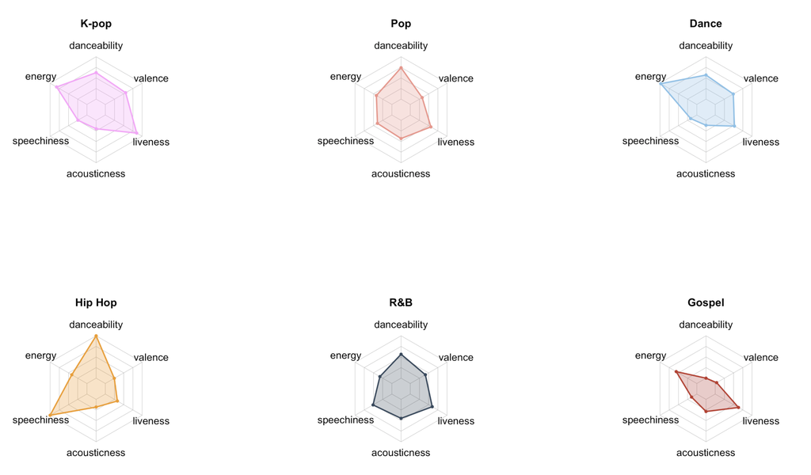

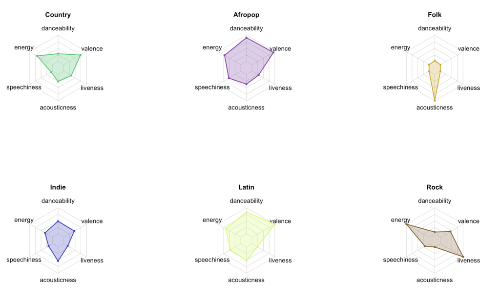

I found these charts very fascinating- you can almost guess the music genre just by looking at these charts and interpreting the audio features. For example, dance is high on “energy,” hip-hop is high on “speechiness,” rock has high “liveness,” and folk is low on everything except from “acousticness.” The audio features seem to predict the genre quite well, and different genres have quite distinct characteristics. Therefore, for this modeling project, I decided to use audio and track features such as “valence,” “energy,” “tempo,” and “popularity” to predict the genre of songs.

### Description of Data

Using the package spotifyr, I retrieved the audio and track characteristics of 2233 tracks from [Spotify Web API](https://developer.spotify.com/documentation/web-api/). The 2233 tracks belong to a total of 11 music genres, all were obtained from Spotify’s year-end “best of” playlists:

- Best of 2019: [Hip-hop](https://open.spotify.com/playlist/37i9dQZF1DX4ykqMZqUn3L?si=2DsMnFNsRv2sLFDY13Yv4Q), [Indie](https://open.spotify.com/playlist/37i9dQZF1DWTc5QDlvD7t0?si=YtH9Av3DQfaHOlGRXi8Mrw), [Gospel](https://open.spotify.com/playlist/37i9dQZF1DX5JHlV94wGBQ?si=O7R4A8N6TQ-jUUMN5jMLog), [Country](https://open.spotify.com/playlist/37i9dQZF1DX3RCeShx2suK?si=jyvlDY_7RViEljyJ-eoJMA), [Dance](https://open.spotify.com/playlist/37i9dQZF1DWYEA2z2jQnzS?si=0GqgtKB4Rae_cfMR-K_Itw), [Rock](https://open.spotify.com/playlist/37i9dQZF1DX5gBZa9tnZTY?si=PkiOmYe2TJ6ivYck3xF_pQ), [Pop](https://open.spotify.com/playlist/37i9dQZF1DXau6DEOS07fE?si=i0hqcsbLQdaWeeLKBgWqHQ), [R&B](https://open.spotify.com/playlist/37i9dQZF1DWT2DKEIZ0ILA?si=dxqtEWahThGNtCcajcww2w), [Afropop](https://open.spotify.com/playlist/37i9dQZF1DXdD040nrEzxm?si=hLGA3kd_R6Ka1XKuem_EKw), [Latin](https://open.spotify.com/playlist/2P3A4oybmznGl3rRXfH6YQ?si=Jk8igHZXQQ-FR70N5yzzZg), [Folk](https://open.spotify.com/playlist/37i9dQZF1DWYdLqwKCcDiy?si=DyGovxvzQMmfLqqM3Q-MEw).
- Best of 2020: [Hip-hop](https://open.spotify.com/playlist/37i9dQZF1DWW5pQp5JqjY4?si=UmNyn9GxRSGtLvvd6SA4ng), [Indie](https://open.spotify.com/playlist/37i9dQZF1DWWkGXMGv9j4M?si=8Jpd8bUORgWuPHuKWxyp9A), [Country](https://open.spotify.com/playlist/37i9dQZF1DWYvU2z6HruAo?si=vOUHnQyOTQmYpsjnqLeEMw), [Dance](https://open.spotify.com/playlist/37i9dQZF1DX6IfVEzIj7ws?si=eiflxUFpRxWRLW3-Dz-kKg), [Rock](https://open.spotify.com/playlist/37i9dQZF1DX2UyG74cWOyT?si=ylXRA3opRQKhZVIbxkLHfA), [Pop](https://open.spotify.com/playlist/37i9dQZF1DX5QPo288x03n?si=HxAD2aDYR9-oUGeXf085Bw), [R&B](https://open.spotify.com/playlist/37i9dQZF1DWVYxTSK0RENg?si=DY9I8Op5QMm3LKrOAK96-A), [Afropop](https://open.spotify.com/playlist/37i9dQZF1DXdD040nrEzxm?si=riSLmuQQStqs7z21ckBwSg), [Latin](https://open.spotify.com/playlist/37i9dQZF1DWT2aDOU7r4aV?si=GbeNYL-FQFOPi6oM_Fhlog), [Folk](https://open.spotify.com/playlist/37i9dQZF1DX4VkeNQew5Ex?si=JBKNr0vMTjaJo7IBTUrnWA).
- Best of the 2010s decade (not including 2020): [Hip-hop](https://open.spotify.com/playlist/37i9dQZF1DX4pjbxDJiPrn?si=vGl1jWH1RH63xJovlUQBpg), [Indie](https://open.spotify.com/playlist/37i9dQZF1DWTHM4kX49UKs?si=MttcUlAWS0KVpOz53z84Rw), [Gospel](https://open.spotify.com/playlist/37i9dQZF1DXaJDplEJVP32?si=Y54H7R4ORSaOwKm1WTD4Tw), [Country](https://open.spotify.com/playlist/37i9dQZF1DXaB64wwvEuUo?si=Awsi4O1IRC2XHRCz9FpRyA), [Dance](https://open.spotify.com/playlist/37i9dQZF1DX8D2YR1GbW3K), [Rock](https://open.spotify.com/playlist/37i9dQZF1DWViLl4FIAFJf?si=2oHqR9rISSm98WZbOJi4cg), [Pop](https://open.spotify.com/playlist/37i9dQZF1DWSs8ya2jFSgv?si=e_Yey8ZKTxKfz5t-EZvv-g), [R&B](https://open.spotify.com/playlist/37i9dQZF1DWXbttAJcbphz), [Afropop](https://open.spotify.com/playlist/37i9dQZF1DWWHMKZF8dZSb?si=kFLrSy-ETiKgXp4HSkEm-g), [Latin](https://open.spotify.com/playlist/37i9dQZF1DWZQkHAMKYFuV?si=8qmwMLBWRY-PnGZ73PcR6Q), [Folk](https://open.spotify.com/playlist/37i9dQZF1DX0dClrg1J8Br?si=3avoPX-pTDSLjk-VoCpokQ).

I pulled track data from each of the playlists above, joined the datasets together, and removed duplicate tracks based on their unique track ID. Since Spotify API doesn’t offer track genre as a variable, I assigned genres to tracks based on the playlists they were from. Using `spotifyr`, I was able to obtain a data frame of 63 variables for each track, and I only selected 14 variables that are most relevant for modeling: the track name, artist name, 11 predictors, and the outcome variable `genre`. The dataset contains information for 2233 tracks, with around 200 tracks from each genre. A detailed walk-through of the data collection and cleaning process can be found in the R scripts, and descriptions of each variable can be found in the codebook “data/processed/tracks_codebook.rtf”.

*Note: in the dataset, `fna` stands for folk & Americana, and `cng` stands for Christian & gospel.*

### Research Questions

- How well does audio and track features such as “energy,” “valence,” and “liveness” predict the genre of a track?
- Which features are the most important or the most frequently used when predicting track genre?

My research is a predictive classification problem, as the response variable (`genre`) is categorical.

## Initial Exploration

First, I will load required packages, set a seed, and read in the processed dataset `tracks`.

```r
# Loading Packages
library(tidyverse)
library(tidymodels)
library(RColorBrewer)
library(cowplot)
library(vip)
# set seed
set.seed(123)
```

```r
# Reading processed dataset
tracks <- read_csv("data/processed/tracks.csv")
```

I will skim the dataset using `skimr::skim_without_charts()` to look for major issues such as missingness.

```r
skimr::skim_without_charts(tracks)
```

Data summary

| Name | tracks |
| --- | --- |
| Number of rows | 2233 |
| Number of columns | 14 |
| _______________________ |  |
| Column type frequency: |  |
| character | 3 |
| numeric | 11 |
| ________________________ |  |
| Group variables | None |

**Variable type: character**

| skim_variable | n_missing | complete_rate | min | max | empty | n_unique | whitespace |
| --- | --- | --- | --- | --- | --- | --- | --- |
| artist.name | 0 | 1 | 1 | 38 | 0 | 1372 | 0 |
| track.name | 0 | 1 | 1 | 102 | 0 | 2162 | 0 |
| genre | 0 | 1 | 3 | 7 | 0 | 11 | 0 |

**Variable type: numeric**

| skim_variable | n_missing | complete_rate | mean | sd | p0 | p25 | p50 | p75 | p100 |
| --- | --- | --- | --- | --- | --- | --- | --- | --- | --- |
| danceability | 0 | 1 | 0.62 | 0.15 | 0.11 | 0.51 | 0.62 | 0.74 | 0.97 |
| energy | 0 | 1 | 0.66 | 0.19 | 0.03 | 0.53 | 0.68 | 0.81 | 1.00 |
| key | 0 | 1 | 5.22 | 3.65 | 0.00 | 2.00 | 5.00 | 8.00 | 11.00 |
| loudness | 0 | 1 | -6.45 | 2.70 | -21.99 | -7.76 | -5.96 | -4.56 | -0.18 |
| speechiness | 0 | 1 | 0.09 | 0.09 | 0.02 | 0.04 | 0.05 | 0.10 | 0.70 |
| acousticness | 0 | 1 | 0.23 | 0.27 | 0.00 | 0.02 | 0.11 | 0.36 | 0.98 |
| instrumentalness | 0 | 1 | 0.05 | 0.15 | 0.00 | 0.00 | 0.00 | 0.00 | 0.94 |
| liveness | 0 | 1 | 0.17 | 0.14 | 0.02 | 0.09 | 0.12 | 0.21 | 0.97 |
| valence | 0 | 1 | 0.48 | 0.22 | 0.04 | 0.30 | 0.47 | 0.64 | 0.98 |
| tempo | 0 | 1 | 120.66 | 28.03 | 48.72 | 98.10 | 121.97 | 138.06 | 208.07 |
| popularity | 0 | 1 | 54.38 | 20.38 | 0.00 | 46.00 | 58.00 | 68.00 | 94.00 |

There are no missingness issues with the dataset. I will convert `genre` into a factor variable. Spotify records `loudness` in decibels (dB), so loudness values are negative, and louder tracks have smaller absolute values (e.g. -5dB is louder than -20dB). Therefore, I will also take the negative reciprocal of `loudness` for ease of understanding.

```r
tracks <- tracks %>%
  mutate(genre = factor(genre),
         loudness = (-1 / loudness))
```

Now let’s explore the outcome variable `genre` and look at the number of tracks in each `genre`:

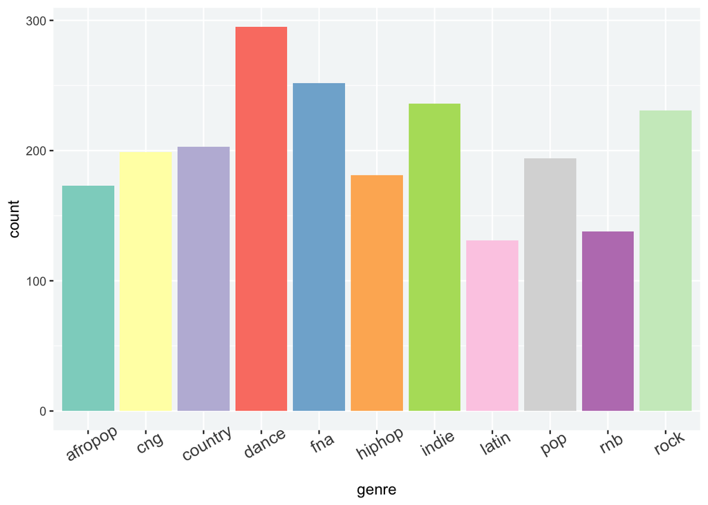

```r
tracks %>%
  ggplot(aes(x = genre, fill = genre)) +
  geom_bar(show.legend = FALSE) +
  theme(axis.text.x = element_text(angle = 30, size = 12),
        panel.background = element_rect(fill="#F4F6F7")) +
  scale_fill_brewer(palette = "Set3")
```

The Spotify playlists I used did not all have an equal number of tracks in them, so we end up with an uneven number of tracks in each `genre`. Therefore, it may be useful to use stratified sampling by `genre`.

Let’s also take a look at how different genres rank on a few features. Here I took the mean `valence`, `liveness`, `acousticness`, and `speechiness` of each genre. Descriptions of these features can be found in the codebook.

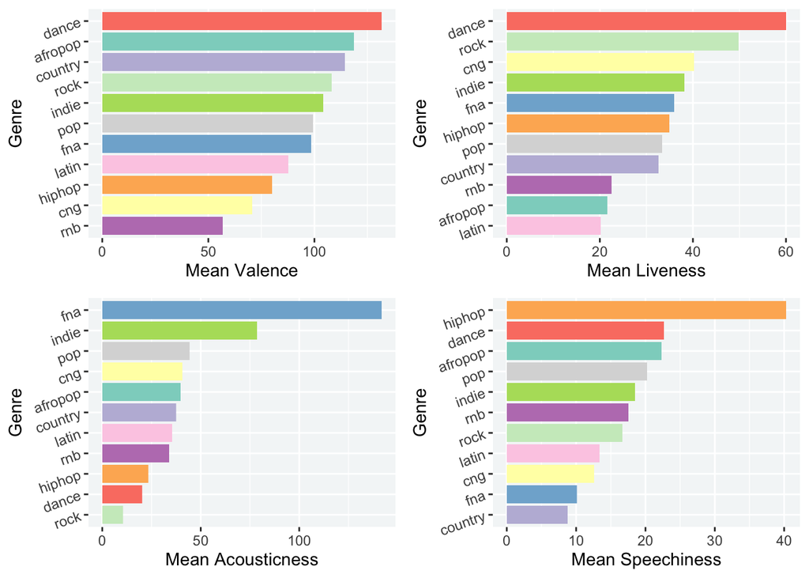

```r
valence <- tracks %>%
  group_by(genre) %>%
  mutate(mean = mean(valence)) %>%
  ggplot(aes(x = reorder(genre, mean, FUN = sum), y = mean)) +
  geom_col(aes(fill = genre), show.legend = FALSE) +
  coord_flip() +
  scale_fill_brewer(palette = "Set3") +
  labs(x = "Genre", y = "Mean Valence") +
  theme(panel.background = element_rect(fill="#F4F6F7"),
        axis.text.y = element_text(angle = 20, size = 9))

liveness <- tracks %>%
  group_by(genre) %>%
  mutate(mean = mean(liveness)) %>%
  ggplot(aes(x = reorder(genre, mean, FUN = sum), y = mean)) +
  geom_col(aes(fill = genre), show.legend = FALSE) +
  coord_flip() +
  scale_fill_brewer(palette = "Set3") +
  labs(x = "Genre", y = "Mean Liveness") +
  theme(panel.background = element_rect(fill="#F4F6F7"),
        axis.text.y = element_text(angle = 20, size = 9))

acousticness <- tracks %>%
  group_by(genre) %>%
  mutate(mean = mean(acousticness)) %>%
  ggplot(aes(x = reorder(genre, mean, FUN = sum), y = mean)) +
  geom_col(aes(fill = genre), show.legend = FALSE) +
  coord_flip() +
  scale_fill_brewer(palette = "Set3") +
  labs(x = "Genre", y = "Mean Acousticness") +
  theme(panel.background = element_rect(fill="#F4F6F7"),
        axis.text.y = element_text(angle = 20, size = 9))

speechiness <- tracks %>%
  group_by(genre) %>%
  mutate(mean = mean(speechiness)) %>%
  ggplot(aes(x = reorder(genre, mean, FUN = sum), y = mean)) +
  geom_col(aes(fill = genre), show.legend = FALSE) +
  coord_flip() +
  scale_fill_brewer(palette = "Set3") +
  labs(x = "Genre", y = "Mean Speechiness") +
  theme(panel.background = element_rect(fill="#F4F6F7"),
        axis.text.y = element_text(angle = 20, size = 9))

plot_grid(valence, liveness, acousticness, speechiness)
```

Dance has the highest mean `valence` and `liveness`, folk & Americana is overall the most acoustic, and hip-hop has the highest `speechiness`. From these graphs we can see that each `genre` performs quite differently on each audio feature, so it should be a good idea to use audio features as predictors for `genre`.

## Modeling

### Splitting Data

First, I will split the dataset into training and testing sets. Since the dataset is quite small, I will allocate 80% to the training set and 20% to the testing set to have more data to train the models.

```r
tracks_split <- initial_split(tracks, prop = 0.8, strata = genre)
tracks_train <- training(tracks_split)
tracks_test <- testing(tracks_split)
```

I have verified that the dimensions of the training and testing sets are proportional and add up to 2233. In order to have a better evaluation of the model performance before applying it to the testing set, I will also use V-fold cross-validation as a resampling method. Again, since the dataset is relatively small, I will use a five-fold cross-validation with 5 repeats.

```r
tracks_folds <- vfold_cv(data = tracks_train, v = 5, repeats = 5)
```

### Recipe

I will create a recipe, predicting `genre` with 11 audio or track features: `danceability`, `energy`, `loudness`, `speechiness`, `acousticness`, `instrumentalness`, `liveness`, `valence`, `tempo`, `key`, and `popularity`. I will also scale and center all predictor variables.

```r
recipe <- recipe(genre ~ danceability + energy + key + loudness + speechiness +
                 acousticness + instrumentalness + liveness + valence +
                 tempo + popularity, data = tracks_train) %>%
  step_normalize(all_predictors())
recipe
```

```
## Data Recipe
##
## Inputs:
##
##       role #variables
##    outcome          1
##  predictor         11
##
## Operations:
##
## Centering and scaling for all_predictors()
```

### Set Engines and Workflows

Since my research question is a multiclass classification problem, I will be trying the following models:  
1. Elastic net (a type of logistic regression), tuning the parameters `penalty` and `mixture`  
2. Random forest (a tree-based model), tuning `mtry` and `min_n`  
3. Boosted tree (a tree-based model), tuning `mtry`, `min_n`, and `learn_rate`  
4. K-nearest neighbors (a non-parametric classification method), tuning `neighbors`.

I will set up the engine and create workflows for each of these models, based on the recipe above.

```r
# elastic net
en_model <- multinom_reg(mode = "classification", penalty = tune(),
                         mixture = tune()) %>%
  set_engine("glmnet")

en_workflow <- workflow() %>%
  add_model(en_model) %>%
  add_recipe(recipe)

# random forest
rf_model <- rand_forest(mode = "classification", mtry = tune(),
                        min_n = tune()) %>%
  set_engine("ranger", importance = "impurity")

rf_workflow <- workflow() %>%
  add_model(rf_model) %>%
  add_recipe(recipe)

# boosted tree
bt_model <- boost_tree(mode = "classification", mtry = tune(),
                       min_n = tune(), learn_rate = tune()) %>%
  set_engine("xgboost", importance = "impurity")

bt_workflow <- workflow() %>%
  add_model(bt_model) %>%
  add_recipe(recipe)

# nearest neighbors
nn_model <- nearest_neighbor(mode = "classification", neighbors = tune()) %>%
  set_engine("kknn")

nn_workflow <- workflow() %>%
  add_model(nn_model) %>%
  add_recipe(recipe)
```

### Tuning with Regular Grids

I will create regular grids with 5 levels for each of the models, tuning the corresponding parameters. The parameter values are decided based on the number of predictors and the size of the dataset.

```r
# elastic net
en_grid <- grid_regular(mixture(), penalty(), levels = 5)

# random forest
rf_params <- parameters(rf_model) %>%
  update(mtry = mtry(range = c(1, 11)))
rf_grid <- grid_regular(rf_params, levels = 5)

# boosted tree
bt_params <- parameters(bt_model) %>%
  update(mtry = mtry(range = c(1, 11)),
         learn_rate = learn_rate(range = c(-10, 0)))
bt_grid <- grid_regular(bt_params, levels = 5)

# nearest neighbors
nn_params <- parameters(nn_model)
nn_grid <- grid_regular(nn_params, levels = 5)
```

Then, I will tune the four models using the workflows and regular grids I just created. Since tuning the models, with the addition of cross-validation, takes a very long time, I have created separate R scripts to run and save the tuned models into RDS files. These can be found in the “rscripts” folder.

```r
# elastic net
en_tuned <- en_workflow %>%
  tune_grid(tracks_folds, grid = en_grid)

# random forest
rf_tuned <- rf_workflow %>%
  tune_grid(tracks_folds, grid = rf_grid)

# boosted tree
bt_tuned <- bt_workflow %>%
  tune_grid(tracks_folds, grid = bt_grid)

# nearest neighbors
nn_tuned <- nn_workflow %>%
  tune_grid(tracks_folds, grid = nn_grid)
```

```r
en_tuned <- read_rds("rscripts/en_model.rds")
rf_tuned <- read_rds("rscripts/rf_model.rds")
bt_tuned <- read_rds("rscripts/bt_model.rds")
nn_tuned <- read_rds("rscripts/nn_model.rds")
```

## Measuring Performance

Since this is a multiclass classification problem, I will use the area under the ROC curve, or `roc_auc` as the performance metric. Let’s take a look at the autoplots and the best-performing parameter values for each model:

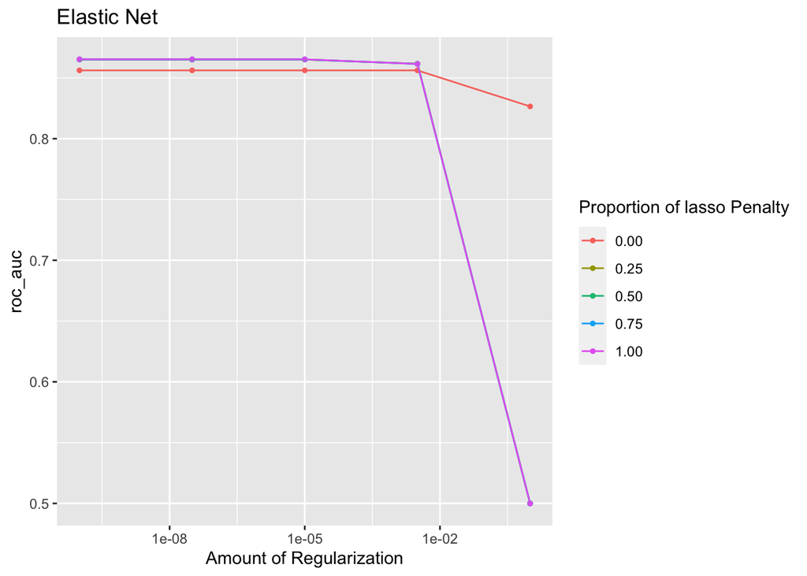

```r
autoplot(en_tuned, metric = "roc_auc") +
  labs(title = "Elastic Net")
```

```r
show_best(en_tuned, metric = "roc_auc")
```

```
## # A tibble: 5 x 8
##        penalty mixture .metric .estimator  mean     n std_err .config
##          <dbl>   <dbl> <chr>   <chr>      <dbl> <int>   <dbl> <chr>
## 1 0.0000000001    1    roc_auc hand_till  0.865    25 0.00212 Preprocessor1_Mod…
## 2 0.0000000316    1    roc_auc hand_till  0.865    25 0.00212 Preprocessor1_Mod…
## 3 0.00001         1    roc_auc hand_till  0.865    25 0.00212 Preprocessor1_Mod…
## 4 0.0000000001    0.75 roc_auc hand_till  0.865    25 0.00213 Preprocessor1_Mod…
## 5 0.0000000316    0.75 roc_auc hand_till  0.865    25 0.00213 Preprocessor1_Mod…
```

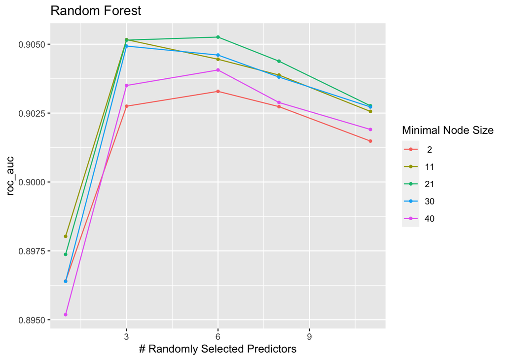

```r
autoplot(rf_tuned, metric = "roc_auc") +
  labs(title = "Random Forest")
```

```r
show_best(rf_tuned, metric = "roc_auc")
```

```
## # A tibble: 5 x 8
##    mtry min_n .metric .estimator  mean     n std_err .config
##   <int> <int> <chr>   <chr>      <dbl> <int>   <dbl> <chr>
## 1     6    21 roc_auc hand_till  0.905    25 0.00173 Preprocessor1_Model13
## 2     3    11 roc_auc hand_till  0.905    25 0.00180 Preprocessor1_Model07
## 3     3    21 roc_auc hand_till  0.905    25 0.00178 Preprocessor1_Model12
## 4     3    30 roc_auc hand_till  0.905    25 0.00184 Preprocessor1_Model17
## 5     6    30 roc_auc hand_till  0.905    25 0.00174 Preprocessor1_Model18
```

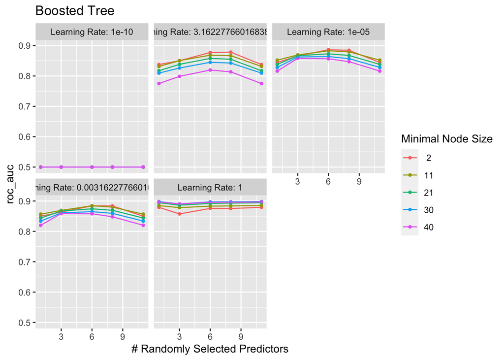

```r
autoplot(bt_tuned, metric = "roc_auc") +
  labs(title = "Boosted Tree")
```

```r
show_best(bt_tuned, metric = "roc_auc")
```

```
## # A tibble: 5 x 9
##    mtry min_n learn_rate .metric .estimator  mean     n std_err .config
##   <int> <int>      <dbl> <chr>   <chr>      <dbl> <int>   <dbl> <chr>
## 1     1    30          1 roc_auc hand_till  0.898    25 0.00230 Preprocessor1_M…
## 2    11    30          1 roc_auc hand_till  0.898    25 0.00230 Preprocessor1_M…
## 3     8    30          1 roc_auc hand_till  0.897    25 0.00185 Preprocessor1_M…
## 4     6    30          1 roc_auc hand_till  0.897    25 0.00215 Preprocessor1_M…
## 5     1    40          1 roc_auc hand_till  0.897    25 0.00214 Preprocessor1_M…
```

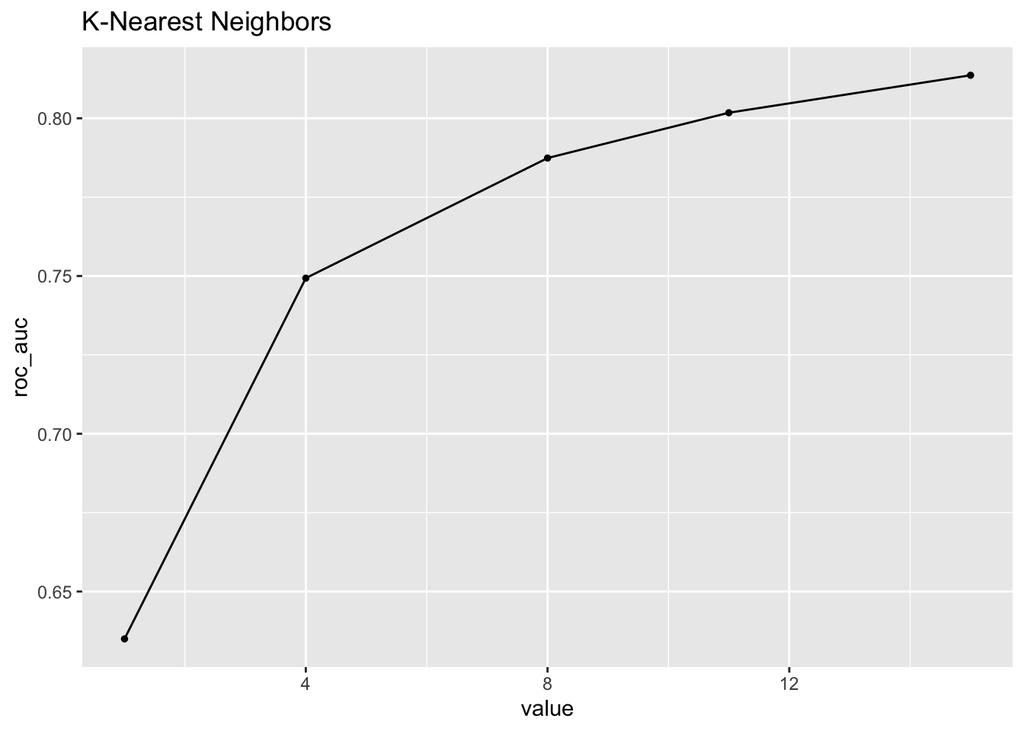

```r
autoplot(nn_tuned, metric = "roc_auc") +
  labs(title = "K-Nearest Neighbors")
```

```r
show_best(nn_tuned, metric = "roc_auc")
```

```
## # A tibble: 5 x 7
##   neighbors .metric .estimator  mean     n std_err .config
##       <int> <chr>   <chr>      <dbl> <int>   <dbl> <chr>
## 1        15 roc_auc hand_till  0.814    25 0.00305 Preprocessor1_Model5
## 2        11 roc_auc hand_till  0.802    25 0.00329 Preprocessor1_Model4
## 3         8 roc_auc hand_till  0.787    25 0.00333 Preprocessor1_Model3
## 4         4 roc_auc hand_till  0.749    25 0.00311 Preprocessor1_Model2
## 5         1 roc_auc hand_till  0.635    25 0.00220 Preprocessor1_Model1
```

Overall, the **random forest model** performed the best. It’s best tuning parameters give a mean AUC value of 0.905 and a very small standard error. An AUC value over 0.9 indicates that the accuracy of the model is [excellent](http://gim.unmc.edu/dxtests/roc3.htm). Nevertheless, all of the models did quite well, with the boosted tree in 2nd place (AUC = 0.898), the elastic net in 3rd place (AUC = 0.865), and the KNN coming in last (AUC = 0.814). Even the KNN has an AUC value that’s over 0.8, which is still considered as good accuracy.

### Finalizing

I will move forward with the random forest model, since it gives the largest area under the ROC curve. I will finalize the model with its best-performing parameter values.

```r
rf_workflow_tuned <- rf_workflow %>%
  finalize_workflow(select_best(rf_tuned, metric = "roc_auc"))
```

## Testing

Finally, I will fit the tuned random forest model to the training data.

```r
rf_results <- fit(rf_workflow_tuned, tracks_train)
```

Let’s apply the model to the testing data, generate class probabilities, and find out the overall AUC value for the model on the testing set.

```r
rf_prediction <- predict(rf_results, new_data = tracks_test, type = "prob") %>%
  bind_cols(truth = tracks_test$genre)

rf_prediction %>%
  roc_auc(truth, starts_with(".pred_"))
```

```
## # A tibble: 1 x 3
##   .metric .estimator .estimate
##   <chr>   <chr>          <dbl>
## 1 roc_auc hand_till      0.906
```

The overall AUC value on the testing set is 0.906, which is quite close to that of the training set and still indicates excellent accuracy.

Now I will plot ROC curves for each genre and also create a confusion matrix for my model, which will help us understand if the model gave equally accurate predictions for each genre.

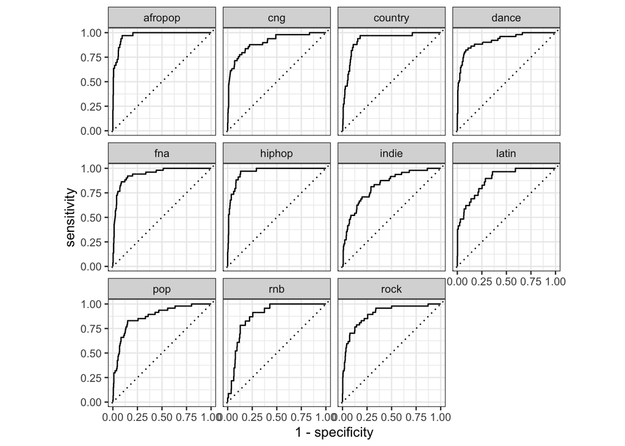

```r
curve <- roc_curve(rf_prediction, truth = truth, starts_with(".pred_"))
autoplot(curve)
```

```r
rf_prediction2 <- predict(rf_results, new_data = tracks_test) %>%
  bind_cols(truth = tracks_test$genre)
conf_mat(rf_prediction2, truth = truth, estimate = .pred_class)
```

```
##           Truth
## Prediction afropop cng country dance fna hiphop indie latin pop rnb rock
##    afropop      23   4       0     2   2      0     4     1   3   5    1
##    cng           0  29       5     2   4      0     0     0   1   1    3
##    country       1   5      22     4   0      1     4     3   2   4    7
##    dance         3   2       0    33   1      0     6     2   5   2    7
##    fna           0   4       1     0  40      0    12     0   0   0    0
##    hiphop        1   0       1     0   1     22     1     4   7   3    1
##    indie         4   1       1     3   3      1    16     2   1   4    1
##    latin         0   0       1     0   0      2     1    11   6   0    0
##    pop           0   1       0     3   0      4     0     4  17   0    1
##    rnb           1   0       1     0   0      4     4     2   2   4    3
##    rock          0   3       1     4   0      0     0     0   3   0   23
```

Last, but not least, I will look at the most important predictors that were the most frequently used in predicting `genre`:

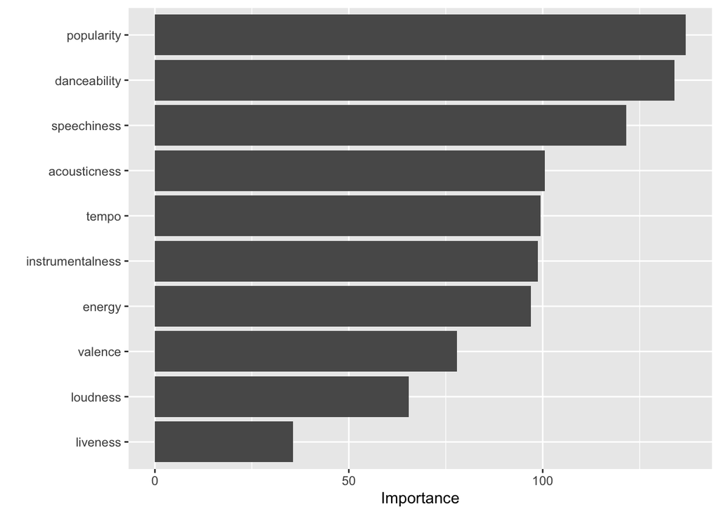

```r
rf_results %>%
  pull_workflow_fit() %>%
  vip()
```

From the variable importance plot, I am surprised to find that the most important predictor is actually `popularity`, instead of an audio feature. This might be because on Spotify, some genres are more frequently streamed, or streamed by more users, than others (for example, pop literally stands for “popular music”). The audio feature `danceablity` is almost as important.

Lastly, I will predict the genre of a few of hit songs just for fun!

The model’s genre prediction for Billie Eilish’s *bad guy*:

```r
badguy <- tracks %>%
  filter(track.name == "bad guy")
predict(rf_results, new_data = badguy)
```

```
## # A tibble: 1 x 1
##   .pred_class
##   <fct>
## 1 pop
```

Seems pretty accurate! What about Kendrick Lamar’s *HUMBLE.*?

```r
humble <- tracks %>%
  filter(track.name == "HUMBLE.")
predict(rf_results, new_data = humble)
```

```
## # A tibble: 1 x 1
##   .pred_class
##   <fct>
## 1 hiphop
```

That seems right too! What about *Mine* by Taylor Swift?

```r
mine <- tracks %>%
  filter(track.name == "Mine")
predict(rf_results, new_data = mine)
```

```
## # A tibble: 1 x 1
##   .pred_class
##   <fct>
## 1 country
```

Yes, pretty sure it’s a title song from her earlier country era! Our model has done well.

## Debrief

In this project, I attempted to build a model that predicts the genre of songs based on the track and audio features. I was able to set up, tune, and fit four models using the training data sets, and the one that performed the best was the random forest model, which had an area under ROC curve of 0.906 on the testing set. Tree-based models may work better for multiclass classification problems because they are decision-based rather than probability-based, and they do not make normality or linearity assumptions about the variables. Overall, my models were quite accurate, which makes me think that Spotify is probably also using these audio features to label music, make personalized user recommendations, and generate playlists.

One way to further improve my model is to look for a more accurate and distinct categorization of `genre` in the first place. For this project, the labeling of genres is solely based on the playlist from which a track is retrieved, which may be a rather arbitrary categorization. In fact, *Shape of You* by Ed Sheeran is labeled as a Latin track in my dataset. I can certainly see its Latin influence and I understand why someone would put it in a Latin playlist, but I would definitely label it as a pop song. The subjective and arbitrary labeling of `genre` might have confused the model. It may also be useful to add more tracks to the model, or add more predictors such as the track length, language of lyrics, and the age and gender of artists.